```python
import pandas as pd
import numpy as np
import matplotlib.pyplot as plt
%matplotlib inline
import requests
import json
from IPython.display import Image
```

# Gathering Data

### import twitter-archive-enhanced-2 file

```python
twitter_archive = pd.read_csv('twitter-archive-enhanced-2.csv')
```

### Download image-predictions.tsv programmatically

```python
url = "https://d17h27t6h515a5.cloudfront.net/topher/2017/August/599fd2ad_image-predictions/image-predictions.tsv"
response = requests.get(url)
with open('image-predictions.tsv', mode = 'wb') as file:
    file.write(response.content)
```

### import data from Twitter API

```python
import tweepy
from tweepy import OAuthHandler
import json
from timeit import default_timer as timer

# Query Twitter API for each tweet in the Twitter archive and save JSON in a text file
# These are hidden to comply with Twitter's API terms and conditions
consumer_key = 'HIDDEN'
consumer_secret = 'HIDDEN'
access_token = 'HIDDEN'
access_secret = 'HIDDEN'

auth = OAuthHandler(consumer_key, consumer_secret)
auth.set_access_token(access_token, access_secret)

api = tweepy.API(auth, wait_on_rate_limit=True)

# NOTE TO STUDENT WITH MOBILE VERIFICATION ISSUES:
# df_1 is a DataFrame with the twitter_archive_enhanced.csv file. You may have to
# change line 17 to match the name of your DataFrame with twitter_archive_enhanced.csv
# NOTE TO REVIEWER: this student had mobile verification issues so the following
# Twitter API code was sent to this student from a Udacity instructor
# Tweet IDs for which to gather additional data via Twitter's API
tweet_ids = df_1.tweet_id.values
len(tweet_ids)

# Query Twitter's API for JSON data for each tweet ID in the Twitter archive
count = 0
fails_dict = {}
start = timer()
# Save each tweet's returned JSON as a new line in a .txt file
with open('tweet_json.txt', 'w') as outfile:
    # This loop will likely take 20-30 minutes to run because of Twitter's rate limit
    for tweet_id in tweet_ids:
        count += 1
        print(str(count) + ": " + str(tweet_id))
        try:
            tweet = api.get_status(tweet_id, tweet_mode='extended')
            print("Success")
            json.dump(tweet._json, outfile)
            outfile.write('\n')
        except tweepy.TweepError as e:
            print("Fail")
            fails_dict[tweet_id] = e
            pass
end = timer()
print(end - start)
print(fails_dict)
```

### import the data manually

```python
# convert 'tweet-json copy' to a list where each line contains one piece of information
df_tweet_list = []
with open('tweet-json copy') as file:
    for line in file:
        df_tweet_list.append(json.loads(line))
```

```python
df_tweet_list[0]
```

```
{'created_at': 'Tue Aug 01 16:23:56 +0000 2017',
 'id': 892420643555336193,
 'id_str': '892420643555336193',
 'full_text': "This is Phineas. He's a mystical boy. Only ever appears in the hole of a donut. 13/10 https://t.co/MgUWQ76dJU",
 'truncated': False,
 'display_text_range': [0, 85],
 'entities': {'hashtags': [],
  'symbols': [],
  'user_mentions': [],
  'urls': [],
  'media': [{'id': 892420639486877696,
    'id_str': '892420639486877696',
    'indices': [86, 109],
    'media_url': 'http://pbs.twimg.com/media/DGKD1-bXoAAIAUK.jpg',
    'media_url_https': 'https://pbs.twimg.com/media/DGKD1-bXoAAIAUK.jpg',
    'url': 'https://t.co/MgUWQ76dJU',
    'display_url': 'pic.twitter.com/MgUWQ76dJU',
    'expanded_url': 'https://twitter.com/dog_rates/status/892420643555336193/photo/1',
    'type': 'photo',
    'sizes': {'large': {'w': 540, 'h': 528, 'resize': 'fit'},
     'thumb': {'w': 150, 'h': 150, 'resize': 'crop'},
     'small': {'w': 540, 'h': 528, 'resize': 'fit'},
     'medium': {'w': 540, 'h': 528, 'resize': 'fit'}}}]},
 'extended_entities': {'media': [{'id': 892420639486877696,
    'id_str': '892420639486877696',
    'indices': [86, 109],
    'media_url': 'http://pbs.twimg.com/media/DGKD1-bXoAAIAUK.jpg',
    'media_url_https': 'https://pbs.twimg.com/media/DGKD1-bXoAAIAUK.jpg',
    'url': 'https://t.co/MgUWQ76dJU',
    'display_url': 'pic.twitter.com/MgUWQ76dJU',
    'expanded_url': 'https://twitter.com/dog_rates/status/892420643555336193/photo/1',
    'type': 'photo',
    'sizes': {'large': {'w': 540, 'h': 528, 'resize': 'fit'},
     'thumb': {'w': 150, 'h': 150, 'resize': 'crop'},
     'small': {'w': 540, 'h': 528, 'resize': 'fit'},
     'medium': {'w': 540, 'h': 528, 'resize': 'fit'}}}]},
 'source': '<a href="http://twitter.com/download/iphone" rel="nofollow">Twitter for iPhone</a>',
 'in_reply_to_status_id': None,
 'in_reply_to_status_id_str': None,
 'in_reply_to_user_id': None,
```

[output cut: 45 more lines]

```
  'follow_request_sent': False,
  'notifications': False,
  'translator_type': 'none'},
 'geo': None,
 'coordinates': None,
 'place': None,
 'contributors': None,
 'is_quote_status': False,
 'retweet_count': 8853,
 'favorite_count': 39467,
 'favorited': False,
 'retweeted': False,
 'possibly_sensitive': False,
 'possibly_sensitive_appealable': False,
 'lang': 'en'}
```

```python
# create a datafrom from tweet-json copy file to get id, retweet_count, favorite_count
df_tweet = pd.DataFrame(df_tweet_list, columns = ['id',
                                                  'retweet_count',
                                                  'favorite_count'])
```

```python
df_tweet.sample(3)
```

|  | id | retweet_count | favorite_count |
| --- | --- | --- | --- |
| 660 | 791026214425268224 | 4858 | 0 |
| 285 | 838831947270979586 | 12643 | 0 |
| 325 | 833826103416520705 | 3904 | 16728 |

```python
# rename the id column to be be named same in all the DataFrames
df_tweet = df_tweet.rename(columns = {'id':'tweet_id'})
```

```python
df_tweet.to_csv('df_tweet.csv', index=False)
```

```python
read = pd.read_csv('df_tweet.csv')
read.head()
```

|  | tweet_id | retweet_count | favorite_count |
| --- | --- | --- | --- |
| 0 | 892420643555336193 | 8853 | 39467 |
| 1 | 892177421306343426 | 6514 | 33819 |
| 2 | 891815181378084864 | 4328 | 25461 |
| 3 | 891689557279858688 | 8964 | 42908 |
| 4 | 891327558926688256 | 9774 | 41048 |

# Assesing Data

### assessing twitter_archive file

```python
# visual assessment
twitter_archive.head(10)
```

|  | tweet_id | in_reply_to_status_id | in_reply_to_user_id | timestamp | source | text | retweeted_status_id | retweeted_status_user_id | retweeted_status_timestamp | expanded_urls | rating_numerator | rating_denominator | name | doggo | floofer | pupper | puppo |
| --- | --- | --- | --- | --- | --- | --- | --- | --- | --- | --- | --- | --- | --- | --- | --- | --- | --- |
| 0 | 892420643555336193 | NaN | NaN | 2017-08-01 16:23:56 +0000 | <a href="http://twitter.com/download/iphone" r... | This is Phineas. He's a mystical boy. Only eve... | NaN | NaN | NaN | https://twitter.com/dog_rates/status/892420643... | 13 | 10 | Phineas | None | None | None | None |
| 1 | 892177421306343426 | NaN | NaN | 2017-08-01 00:17:27 +0000 | <a href="http://twitter.com/download/iphone" r... | This is Tilly. She's just checking pup on you.... | NaN | NaN | NaN | https://twitter.com/dog_rates/status/892177421... | 13 | 10 | Tilly | None | None | None | None |
| 2 | 891815181378084864 | NaN | NaN | 2017-07-31 00:18:03 +0000 | <a href="http://twitter.com/download/iphone" r... | This is Archie. He is a rare Norwegian Pouncin... | NaN | NaN | NaN | https://twitter.com/dog_rates/status/891815181... | 12 | 10 | Archie | None | None | None | None |
| 3 | 891689557279858688 | NaN | NaN | 2017-07-30 15:58:51 +0000 | <a href="http://twitter.com/download/iphone" r... | This is Darla. She commenced a snooze mid meal... | NaN | NaN | NaN | https://twitter.com/dog_rates/status/891689557... | 13 | 10 | Darla | None | None | None | None |
| 4 | 891327558926688256 | NaN | NaN | 2017-07-29 16:00:24 +0000 | <a href="http://twitter.com/download/iphone" r... | This is Franklin. He would like you to stop ca... | NaN | NaN | NaN | https://twitter.com/dog_rates/status/891327558... | 12 | 10 | Franklin | None | None | None | None |
| 5 | 891087950875897856 | NaN | NaN | 2017-07-29 00:08:17 +0000 | <a href="http://twitter.com/download/iphone" r... | Here we have a majestic great white breaching ... | NaN | NaN | NaN | https://twitter.com/dog_rates/status/891087950... | 13 | 10 | None | None | None | None | None |
| 6 | 890971913173991426 | NaN | NaN | 2017-07-28 16:27:12 +0000 | <a href="http://twitter.com/download/iphone" r... | Meet Jax. He enjoys ice cream so much he gets ... | NaN | NaN | NaN | https://gofundme.com/ydvmve-surgery-for-jax,ht... | 13 | 10 | Jax | None | None | None | None |
| 7 | 890729181411237888 | NaN | NaN | 2017-07-28 00:22:40 +0000 | <a href="http://twitter.com/download/iphone" r... | When you watch your owner call another dog a g... | NaN | NaN | NaN | https://twitter.com/dog_rates/status/890729181... | 13 | 10 | None | None | None | None | None |
| 8 | 890609185150312448 | NaN | NaN | 2017-07-27 16:25:51 +0000 | <a href="http://twitter.com/download/iphone" r... | This is Zoey. She doesn't want to be one of th... | NaN | NaN | NaN | https://twitter.com/dog_rates/status/890609185... | 13 | 10 | Zoey | None | None | None | None |
| 9 | 890240255349198849 | NaN | NaN | 2017-07-26 15:59:51 +0000 | <a href="http://twitter.com/download/iphone" r... | This is Cassie. She is a college pup. Studying... | NaN | NaN | NaN | https://twitter.com/dog_rates/status/890240255... | 14 | 10 | Cassie | doggo | None | None | None |

```python
twitter_archive.tail(10)
```

|  | tweet_id | in_reply_to_status_id | in_reply_to_user_id | timestamp | source | text | retweeted_status_id | retweeted_status_user_id | retweeted_status_timestamp | expanded_urls | rating_numerator | rating_denominator | name | doggo | floofer | pupper | puppo |
| --- | --- | --- | --- | --- | --- | --- | --- | --- | --- | --- | --- | --- | --- | --- | --- | --- | --- |
| 2346 | 666058600524156928 | NaN | NaN | 2015-11-16 01:01:59 +0000 | <a href="http://twitter.com/download/iphone" r... | Here is the Rand Paul of retrievers folks! He'... | NaN | NaN | NaN | https://twitter.com/dog_rates/status/666058600... | 8 | 10 | the | None | None | None | None |
| 2347 | 666057090499244032 | NaN | NaN | 2015-11-16 00:55:59 +0000 | <a href="http://twitter.com/download/iphone" r... | My oh my. This is a rare blond Canadian terrie... | NaN | NaN | NaN | https://twitter.com/dog_rates/status/666057090... | 9 | 10 | a | None | None | None | None |
| 2348 | 666055525042405380 | NaN | NaN | 2015-11-16 00:49:46 +0000 | <a href="http://twitter.com/download/iphone" r... | Here is a Siberian heavily armored polar bear ... | NaN | NaN | NaN | https://twitter.com/dog_rates/status/666055525... | 10 | 10 | a | None | None | None | None |
| 2349 | 666051853826850816 | NaN | NaN | 2015-11-16 00:35:11 +0000 | <a href="http://twitter.com/download/iphone" r... | This is an odd dog. Hard on the outside but lo... | NaN | NaN | NaN | https://twitter.com/dog_rates/status/666051853... | 2 | 10 | an | None | None | None | None |
| 2350 | 666050758794694657 | NaN | NaN | 2015-11-16 00:30:50 +0000 | <a href="http://twitter.com/download/iphone" r... | This is a truly beautiful English Wilson Staff... | NaN | NaN | NaN | https://twitter.com/dog_rates/status/666050758... | 10 | 10 | a | None | None | None | None |
| 2351 | 666049248165822465 | NaN | NaN | 2015-11-16 00:24:50 +0000 | <a href="http://twitter.com/download/iphone" r... | Here we have a 1949 1st generation vulpix. Enj... | NaN | NaN | NaN | https://twitter.com/dog_rates/status/666049248... | 5 | 10 | None | None | None | None | None |
| 2352 | 666044226329800704 | NaN | NaN | 2015-11-16 00:04:52 +0000 | <a href="http://twitter.com/download/iphone" r... | This is a purebred Piers Morgan. Loves to Netf... | NaN | NaN | NaN | https://twitter.com/dog_rates/status/666044226... | 6 | 10 | a | None | None | None | None |
| 2353 | 666033412701032449 | NaN | NaN | 2015-11-15 23:21:54 +0000 | <a href="http://twitter.com/download/iphone" r... | Here is a very happy pup. Big fan of well-main... | NaN | NaN | NaN | https://twitter.com/dog_rates/status/666033412... | 9 | 10 | a | None | None | None | None |
| 2354 | 666029285002620928 | NaN | NaN | 2015-11-15 23:05:30 +0000 | <a href="http://twitter.com/download/iphone" r... | This is a western brown Mitsubishi terrier. Up... | NaN | NaN | NaN | https://twitter.com/dog_rates/status/666029285... | 7 | 10 | a | None | None | None | None |
| 2355 | 666020888022790149 | NaN | NaN | 2015-11-15 22:32:08 +0000 | <a href="http://twitter.com/download/iphone" r... | Here we have a Japanese Irish Setter. Lost eye... | NaN | NaN | NaN | https://twitter.com/dog_rates/status/666020888... | 8 | 10 | None | None | None | None | None |

```python
# Programmatic assessment
twitter_archive.info()
```

```
<class 'pandas.core.frame.DataFrame'>
RangeIndex: 2356 entries, 0 to 2355
Data columns (total 17 columns):
tweet_id                      2356 non-null int64
in_reply_to_status_id         78 non-null float64
in_reply_to_user_id           78 non-null float64
timestamp                     2356 non-null object
source                        2356 non-null object
text                          2356 non-null object
retweeted_status_id           181 non-null float64
retweeted_status_user_id      181 non-null float64
retweeted_status_timestamp    181 non-null object
expanded_urls                 2297 non-null object
rating_numerator              2356 non-null int64
rating_denominator            2356 non-null int64
name                          2356 non-null object
doggo                         2356 non-null object
floofer                       2356 non-null object
pupper                        2356 non-null object
puppo                         2356 non-null object
dtypes: float64(4), int64(3), object(10)
memory usage: 313.0+ KB
```

```python
twitter_archive.name
```

```
0        Phineas
1          Tilly
2         Archie
3          Darla
4       Franklin
5           None
6            Jax
7           None
8           Zoey
9         Cassie
10          Koda
11         Bruno
12          None
13           Ted
14        Stuart
```

[output cut: 47 more lines]

```python
twitter_archive.rating_numerator.describe()
```

```
count    2356.000000
mean       13.126486
std        45.876648
min         0.000000
25%        10.000000
50%        11.000000
75%        12.000000
max      1776.000000
Name: rating_numerator, dtype: float64
```

```python
# checking the count of ids that have rating_numerator less than 10
twitter_archive[twitter_archive.rating_numerator < 10].count()[0]
```

```
440
```

```python
twitter_archive.rating_denominator.describe()
```

```
count    2356.000000
mean       10.455433
std         6.745237
min         0.000000
25%        10.000000
50%        10.000000
75%        10.000000
max       170.000000
Name: rating_denominator, dtype: float64
```

```python
# checking the count of ids that have rating_denominator more than 10
twitter_archive[twitter_archive.rating_denominator > 10].count()[0]
```

```
20
```

```python
twitter_archive.name.value_counts()
```

```
None        745
a            55
Charlie      12
Cooper       11
Lucy         11
Oliver       11
Lola         10
Tucker       10
Penny        10
Winston       9
Bo            9
the           8
Sadie         8
Buddy         7
an            7
Daisy         7
Bailey        7
Toby          7
Dave          6
Jax           6
Scout         6
Leo           6
Rusty         6
Koda          6
Oscar         6
Stanley       6
Jack          6
Bella         6
Milo          6
George        5
           ...
Fabio         1
Joey          1
Mo            1
Ambrose       1
Einstein      1
Bobble        1
Tino          1
Rooney        1
Pawnd         1
Kenzie        1
Halo          1
Claude        1
Cedrick       1
Striker       1
Cannon        1
Traviss       1
Brownie       1
Tommy         1
Mollie        1
such          1
Kota          1
Duddles       1
Pilot         1
Arnold        1
Clarq         1
Jazzy         1
Ginger        1
Superpup      1
Henry         1
Banditt       1
Name: name, Length: 957, dtype: int64
```

```python
twitter_archive.name.unique
```

```
<bound method Series.unique of 0        Phineas
1          Tilly
2         Archie
3          Darla
4       Franklin
5           None
6            Jax
7           None
8           Zoey
9         Cassie
10          Koda
11         Bruno
12          None
13           Ted
14        Stuart
```

[output cut: 47 more lines]

### assessing image-predictions

```python
img_pre = pd.read_csv('image-predictions.tsv', sep='\t')
img_pre.head(10)
```

|  | tweet_id | jpg_url | img_num | p1 | p1_conf | p1_dog | p2 | p2_conf | p2_dog | p3 | p3_conf | p3_dog |
| --- | --- | --- | --- | --- | --- | --- | --- | --- | --- | --- | --- | --- |
| 0 | 666020888022790149 | https://pbs.twimg.com/media/CT4udn0WwAA0aMy.jpg | 1 | Welsh_springer_spaniel | 0.465074 | True | collie | 0.156665 | True | Shetland_sheepdog | 0.061428 | True |
| 1 | 666029285002620928 | https://pbs.twimg.com/media/CT42GRgUYAA5iDo.jpg | 1 | redbone | 0.506826 | True | miniature_pinscher | 0.074192 | True | Rhodesian_ridgeback | 0.072010 | True |
| 2 | 666033412701032449 | https://pbs.twimg.com/media/CT4521TWwAEvMyu.jpg | 1 | German_shepherd | 0.596461 | True | malinois | 0.138584 | True | bloodhound | 0.116197 | True |
| 3 | 666044226329800704 | https://pbs.twimg.com/media/CT5Dr8HUEAA-lEu.jpg | 1 | Rhodesian_ridgeback | 0.408143 | True | redbone | 0.360687 | True | miniature_pinscher | 0.222752 | True |
| 4 | 666049248165822465 | https://pbs.twimg.com/media/CT5IQmsXIAAKY4A.jpg | 1 | miniature_pinscher | 0.560311 | True | Rottweiler | 0.243682 | True | Doberman | 0.154629 | True |
| 5 | 666050758794694657 | https://pbs.twimg.com/media/CT5Jof1WUAEuVxN.jpg | 1 | Bernese_mountain_dog | 0.651137 | True | English_springer | 0.263788 | True | Greater_Swiss_Mountain_dog | 0.016199 | True |
| 6 | 666051853826850816 | https://pbs.twimg.com/media/CT5KoJ1WoAAJash.jpg | 1 | box_turtle | 0.933012 | False | mud_turtle | 0.045885 | False | terrapin | 0.017885 | False |
| 7 | 666055525042405380 | https://pbs.twimg.com/media/CT5N9tpXIAAifs1.jpg | 1 | chow | 0.692517 | True | Tibetan_mastiff | 0.058279 | True | fur_coat | 0.054449 | False |
| 8 | 666057090499244032 | https://pbs.twimg.com/media/CT5PY90WoAAQGLo.jpg | 1 | shopping_cart | 0.962465 | False | shopping_basket | 0.014594 | False | golden_retriever | 0.007959 | True |
| 9 | 666058600524156928 | https://pbs.twimg.com/media/CT5Qw94XAAA_2dP.jpg | 1 | miniature_poodle | 0.201493 | True | komondor | 0.192305 | True | soft-coated_wheaten_terrier | 0.082086 | True |

```python
img_pre.sample(20)
```

|  | tweet_id | jpg_url | img_num | p1 | p1_conf | p1_dog | p2 | p2_conf | p2_dog | p3 | p3_conf | p3_dog |
| --- | --- | --- | --- | --- | --- | --- | --- | --- | --- | --- | --- | --- |
| 2017 | 880095782870896641 | https://pbs.twimg.com/media/DDa6ckbXgAAM1vV.jpg | 1 | miniature_pinscher | 0.120298 | True | Rhodesian_ridgeback | 0.106395 | True | beagle | 0.106073 | True |
| 1847 | 839290600511926273 | https://pbs.twimg.com/media/C6XBt9XXEAEEW9U.jpg | 1 | web_site | 0.670892 | False | monitor | 0.101565 | False | screen | 0.075306 | False |
| 446 | 674664755118911488 | https://pbs.twimg.com/media/CVzkA7-WsAAcXz6.jpg | 1 | African_crocodile | 0.330625 | False | American_alligator | 0.075356 | False | mink | 0.057481 | False |
| 635 | 681231109724700672 | https://pbs.twimg.com/media/CXQ4EwQWwAEVaUf.jpg | 1 | Irish_setter | 0.406047 | True | cocker_spaniel | 0.345646 | True | Airedale | 0.147912 | True |
| 890 | 699323444782047232 | https://pbs.twimg.com/media/CbR-9edXIAEHJKi.jpg | 1 | Labrador_retriever | 0.309696 | True | doormat | 0.303700 | False | sliding_door | 0.077266 | False |
| 1972 | 869596645499047938 | https://pbs.twimg.com/media/DBFtiYqWAAAsjj1.jpg | 1 | Chihuahua | 0.955156 | True | toy_terrier | 0.008054 | True | muzzle | 0.006296 | False |
| 541 | 677187300187611136 | https://pbs.twimg.com/media/CWXaQMBWcAAATDi.jpg | 1 | English_setter | 0.282396 | True | Shih-Tzu | 0.084112 | True | Old_English_sheepdog | 0.059538 | True |
| 630 | 680934982542561280 | https://pbs.twimg.com/media/CXMqwIQWcAA2iE0.jpg | 1 | Labrador_retriever | 0.784398 | True | Siberian_husky | 0.055925 | True | beagle | 0.022750 | True |
| 1414 | 771014301343748096 | https://pbs.twimg.com/media/CrMxZzgWIAQUxzx.jpg | 1 | meerkat | 0.202335 | False | doormat | 0.111790 | False | macaque | 0.088925 | False |
| 457 | 674781762103414784 | https://pbs.twimg.com/media/CV1ObvEWcAA7c6i.jpg | 1 | ocarina | 0.148975 | False | hamster | 0.068985 | False | wool | 0.031728 | False |
| 579 | 678764513869611008 | https://pbs.twimg.com/media/CWt0ubZWcAAkFER.jpg | 1 | Irish_terrier | 0.696646 | True | Australian_terrier | 0.074962 | True | Irish_setter | 0.063901 | True |
| 1351 | 759846353224826880 | https://pbs.twimg.com/media/CouEOZhWAAAgFpE.jpg | 1 | Sussex_spaniel | 0.355395 | True | vizsla | 0.141094 | True | otterhound | 0.092198 | True |
| 1913 | 854010172552949760 | https://pbs.twimg.com/media/C9oNt91WAAAFSLS.jpg | 1 | English_springer | 0.354733 | True | collie | 0.177538 | True | Border_collie | 0.131706 | True |
| 1899 | 851224888060895234 | https://pbs.twimg.com/media/C9AohFoWsAUmxDs.jpg | 3 | car_mirror | 0.971512 | False | seat_belt | 0.007063 | False | standard_poodle | 0.005683 | True |
| 618 | 680221482581123072 | https://pbs.twimg.com/media/CXCh0QZW8AALdXm.jpg | 1 | bubble | 0.240173 | False | hen | 0.146222 | False | abaya | 0.139342 | False |
| 52 | 666996132027977728 | https://pbs.twimg.com/media/CUGlb6iUwAITEbW.jpg | 1 | hay | 0.507637 | False | Rottweiler | 0.062490 | True | water_buffalo | 0.048425 | False |
| 802 | 691459709405118465 | https://pbs.twimg.com/media/CZiO7mWUEAAa4zo.jpg | 1 | Shetland_sheepdog | 0.551206 | True | collie | 0.232544 | True | Border_collie | 0.095218 | True |
| 1877 | 846042936437604353 | https://pbs.twimg.com/media/C72_iaUVUAEhZSn.jpg | 1 | golden_retriever | 0.961110 | True | Labrador_retriever | 0.016695 | True | Tibetan_mastiff | 0.009082 | True |
| 208 | 669970042633789440 | https://pbs.twimg.com/media/CUw2MV4XIAAHLO_.jpg | 1 | miniature_pinscher | 0.734744 | True | Rottweiler | 0.131066 | True | Doberman | 0.081509 | True |
| 422 | 674051556661161984 | https://pbs.twimg.com/media/CVq2UHwWEAAduMw.jpg | 1 | Shih-Tzu | 0.179777 | True | badger | 0.160580 | False | three-toed_sloth | 0.132154 | False |

```python
img_pre.tail(10)
```

|  | tweet_id | jpg_url | img_num | p1 | p1_conf | p1_dog | p2 | p2_conf | p2_dog | p3 | p3_conf | p3_dog |
| --- | --- | --- | --- | --- | --- | --- | --- | --- | --- | --- | --- | --- |
| 2065 | 890240255349198849 | https://pbs.twimg.com/media/DFrEyVuW0AAO3t9.jpg | 1 | Pembroke | 0.511319 | True | Cardigan | 0.451038 | True | Chihuahua | 0.029248 | True |
| 2066 | 890609185150312448 | https://pbs.twimg.com/media/DFwUU__XcAEpyXI.jpg | 1 | Irish_terrier | 0.487574 | True | Irish_setter | 0.193054 | True | Chesapeake_Bay_retriever | 0.118184 | True |
| 2067 | 890729181411237888 | https://pbs.twimg.com/media/DFyBahAVwAAhUTd.jpg | 2 | Pomeranian | 0.566142 | True | Eskimo_dog | 0.178406 | True | Pembroke | 0.076507 | True |
| 2068 | 890971913173991426 | https://pbs.twimg.com/media/DF1eOmZXUAALUcq.jpg | 1 | Appenzeller | 0.341703 | True | Border_collie | 0.199287 | True | ice_lolly | 0.193548 | False |
| 2069 | 891087950875897856 | https://pbs.twimg.com/media/DF3HwyEWsAABqE6.jpg | 1 | Chesapeake_Bay_retriever | 0.425595 | True | Irish_terrier | 0.116317 | True | Indian_elephant | 0.076902 | False |
| 2070 | 891327558926688256 | https://pbs.twimg.com/media/DF6hr6BUMAAzZgT.jpg | 2 | basset | 0.555712 | True | English_springer | 0.225770 | True | German_short-haired_pointer | 0.175219 | True |
| 2071 | 891689557279858688 | https://pbs.twimg.com/media/DF_q7IAWsAEuuN8.jpg | 1 | paper_towel | 0.170278 | False | Labrador_retriever | 0.168086 | True | spatula | 0.040836 | False |
| 2072 | 891815181378084864 | https://pbs.twimg.com/media/DGBdLU1WsAANxJ9.jpg | 1 | Chihuahua | 0.716012 | True | malamute | 0.078253 | True | kelpie | 0.031379 | True |
| 2073 | 892177421306343426 | https://pbs.twimg.com/media/DGGmoV4XsAAUL6n.jpg | 1 | Chihuahua | 0.323581 | True | Pekinese | 0.090647 | True | papillon | 0.068957 | True |
| 2074 | 892420643555336193 | https://pbs.twimg.com/media/DGKD1-bXoAAIAUK.jpg | 1 | orange | 0.097049 | False | bagel | 0.085851 | False | banana | 0.076110 | False |

```python
# diaply Siamese_cat
img_pre.loc[946, 'jpg_url']
```

```
'https://pbs.twimg.com/media/Ccbi0UGWoAA4fwg.jpg'
```

```python
Image(url = 'https://pbs.twimg.com/media/Ccbi0UGWoAA4fwg.jpg')
```

[figure not shown]

```python
img_pre.info()
```

```
<class 'pandas.core.frame.DataFrame'>
RangeIndex: 2075 entries, 0 to 2074
Data columns (total 12 columns):
tweet_id    2075 non-null int64
jpg_url     2075 non-null object
img_num     2075 non-null int64
p1          2075 non-null object
p1_conf     2075 non-null float64
p1_dog      2075 non-null bool
p2          2075 non-null object
p2_conf     2075 non-null float64
p2_dog      2075 non-null bool
p3          2075 non-null object
p3_conf     2075 non-null float64
p3_dog      2075 non-null bool
dtypes: bool(3), float64(3), int64(2), object(4)
memory usage: 152.1+ KB
```

### Assessing tweet-json file

```python
df_tweet.head(10)
```

|  | tweet_id | retweet_count | favorite_count |
| --- | --- | --- | --- |
| 0 | 892420643555336193 | 8853 | 39467 |
| 1 | 892177421306343426 | 6514 | 33819 |
| 2 | 891815181378084864 | 4328 | 25461 |
| 3 | 891689557279858688 | 8964 | 42908 |
| 4 | 891327558926688256 | 9774 | 41048 |
| 5 | 891087950875897856 | 3261 | 20562 |
| 6 | 890971913173991426 | 2158 | 12041 |
| 7 | 890729181411237888 | 16716 | 56848 |
| 8 | 890609185150312448 | 4429 | 28226 |
| 9 | 890240255349198849 | 7711 | 32467 |

```python
df_tweet.sample(10)
```

|  | tweet_id | retweet_count | favorite_count |
| --- | --- | --- | --- |
| 1375 | 701601587219795968 | 523 | 2299 |
| 2338 | 666099513787052032 | 73 | 164 |
| 1927 | 674042553264685056 | 142 | 772 |
| 714 | 783839966405230592 | 12643 | 33689 |
| 77 | 877611172832227328 | 83 | 0 |
| 2284 | 667182792070062081 | 6618 | 15075 |
| 1687 | 681340665377193984 | 313 | 1803 |
| 2023 | 671882082306625538 | 1488 | 3693 |
| 1724 | 680055455951884288 | 8067 | 18278 |
| 2240 | 667911425562669056 | 329 | 523 |

```python
df_tweet.tail(10)
```

|  | tweet_id | retweet_count | favorite_count |
| --- | --- | --- | --- |
| 2344 | 666058600524156928 | 61 | 115 |
| 2345 | 666057090499244032 | 146 | 304 |
| 2346 | 666055525042405380 | 261 | 448 |
| 2347 | 666051853826850816 | 879 | 1253 |
| 2348 | 666050758794694657 | 60 | 136 |
| 2349 | 666049248165822465 | 41 | 111 |
| 2350 | 666044226329800704 | 147 | 311 |
| 2351 | 666033412701032449 | 47 | 128 |
| 2352 | 666029285002620928 | 48 | 132 |
| 2353 | 666020888022790149 | 532 | 2535 |

```python
df_tweet.info()
```

```
<class 'pandas.core.frame.DataFrame'>
RangeIndex: 2354 entries, 0 to 2353
Data columns (total 3 columns):
tweet_id          2354 non-null int64
retweet_count     2354 non-null int64
favorite_count    2354 non-null int64
dtypes: int64(3)
memory usage: 55.2 KB
```

### Tidiness issues

1- doggo, floofer, pupper and puppo columns should be in one column

2- all data frames shoud be in one data frame

### Quality issues

1- tweet_id column is int instead of string

2- timestamp column is string instead of datetime

3- The ratings are not extracted correctly especially decimals.

4- rating_numerator has values less than 10

5- rating_denominator has values more than 10

6- there are alot of retweets that we don't need

7- There are some missing images in image-predictions.tsv file

8- There are some missing values in twitter API data

9- The tweet_id column should be named same in all the DataFrames and it's datatype should be same in all the tables

# Cleaning Data

```python
# creating copies
twitter_archive_clean = twitter_archive.copy()
img_pre_clean = img_pre.copy()
df_tweet_clean = df_tweet.copy()
```

### Code

```python
# handle none
twitter_archive_clean.doggo.replace('None', '', inplace=True)
twitter_archive_clean.floofer.replace('None', '', inplace=True)
twitter_archive_clean.pupper.replace('None', '', inplace=True)
twitter_archive_clean.puppo.replace('None', '', inplace=True)
```

```python
# merge into column
twitter_archive_clean['dog_stage'] = twitter_archive_clean.doggo + twitter_archive_clean.floofer + twitter_archive_clean.pupper + twitter_archive_clean.puppo
```

```python
# handle multiple stages
twitter_archive_clean.loc[twitter_archive_clean.dog_stage == 'doggopupper', 'dog_stage'] = 'doggo, pupper'
twitter_archive_clean.loc[twitter_archive_clean.dog_stage == 'doggopuppo', 'dog_stage'] = 'doggo, puppo'
twitter_archive_clean.loc[twitter_archive_clean.dog_stage == 'doggofloofer', 'dog_stage'] = 'doggo, floofer'
```

```python
# handle missing values
twitter_archive_clean.loc[twitter_archive_clean.dog_stage == '', 'dog_stage'] = np.nan
```

### Test

```python
twitter_archive_clean.info()
```

```
<class 'pandas.core.frame.DataFrame'>
RangeIndex: 2356 entries, 0 to 2355
Data columns (total 18 columns):
tweet_id                      2356 non-null int64
in_reply_to_status_id         78 non-null float64
in_reply_to_user_id           78 non-null float64
timestamp                     2356 non-null object
source                        2356 non-null object
text                          2356 non-null object
retweeted_status_id           181 non-null float64
retweeted_status_user_id      181 non-null float64
retweeted_status_timestamp    181 non-null object
expanded_urls                 2297 non-null object
rating_numerator              2356 non-null int64
rating_denominator            2356 non-null int64
name                          2356 non-null object
doggo                         2356 non-null object
floofer                       2356 non-null object
pupper                        2356 non-null object
puppo                         2356 non-null object
dog_stage                     380 non-null object
dtypes: float64(4), int64(3), object(11)
memory usage: 331.4+ KB
```

### Define

merge all data frames in one data frame

### Code

```python
twitter_archive_clean = pd.merge(twitter_archive_clean, df_tweet_clean, on='tweet_id', how='left')

twitter_archive_clean = pd.merge(twitter_archive_clean, img_pre_clean, on='tweet_id', how='left')
```

### Test

```python
twitter_archive_clean.info()
```

```
<class 'pandas.core.frame.DataFrame'>
Int64Index: 2356 entries, 0 to 2355
Data columns (total 31 columns):
tweet_id                      2356 non-null int64
in_reply_to_status_id         78 non-null float64
in_reply_to_user_id           78 non-null float64
timestamp                     2356 non-null object
source                        2356 non-null object
text                          2356 non-null object
retweeted_status_id           181 non-null float64
retweeted_status_user_id      181 non-null float64
retweeted_status_timestamp    181 non-null object
expanded_urls                 2297 non-null object
rating_numerator              2356 non-null int64
rating_denominator            2356 non-null int64
name                          2356 non-null object
doggo                         2356 non-null object
floofer                       2356 non-null object
pupper                        2356 non-null object
puppo                         2356 non-null object
dog_stage                     380 non-null object
retweet_count                 2354 non-null float64
favorite_count                2354 non-null float64
jpg_url                       2075 non-null object
img_num                       2075 non-null float64
p1                            2075 non-null object
p1_conf                       2075 non-null float64
p1_dog                        2075 non-null object
p2                            2075 non-null object
p2_conf                       2075 non-null float64
p2_dog                        2075 non-null object
p3                            2075 non-null object
p3_conf                       2075 non-null float64
p3_dog                        2075 non-null object
dtypes: float64(10), int64(3), object(18)
memory usage: 589.0+ KB
```

### Define

convert tweet_id columns to string

### Code

```python
twitter_archive_clean.tweet_id = twitter_archive_clean.tweet_id.astype(str)
```

### Test

```python
twitter_archive_clean.info()
```

```
<class 'pandas.core.frame.DataFrame'>
Int64Index: 2356 entries, 0 to 2355
Data columns (total 31 columns):
tweet_id                      2356 non-null object
in_reply_to_status_id         78 non-null float64
in_reply_to_user_id           78 non-null float64
timestamp                     2356 non-null object
source                        2356 non-null object
text                          2356 non-null object
retweeted_status_id           181 non-null float64
retweeted_status_user_id      181 non-null float64
retweeted_status_timestamp    181 non-null object
expanded_urls                 2297 non-null object
rating_numerator              2356 non-null int64
rating_denominator            2356 non-null int64
name                          2356 non-null object
doggo                         2356 non-null object
floofer                       2356 non-null object
pupper                        2356 non-null object
puppo                         2356 non-null object
dog_stage                     380 non-null object
retweet_count                 2354 non-null float64
favorite_count                2354 non-null float64
jpg_url                       2075 non-null object
img_num                       2075 non-null float64
p1                            2075 non-null object
p1_conf                       2075 non-null float64
p1_dog                        2075 non-null object
p2                            2075 non-null object
p2_conf                       2075 non-null float64
p2_dog                        2075 non-null object
p3                            2075 non-null object
p3_conf                       2075 non-null float64
p3_dog                        2075 non-null object
dtypes: float64(10), int64(2), object(19)
memory usage: 589.0+ KB
```

### Define

convert timestamp to datetime

### Code

```python
twitter_archive_clean.timestamp = pd.to_datetime(twitter_archive_clean.timestamp)
```

### Test

```python
twitter_archive_clean.info()
```

```
<class 'pandas.core.frame.DataFrame'>
Int64Index: 2356 entries, 0 to 2355
Data columns (total 31 columns):
tweet_id                      2356 non-null object
in_reply_to_status_id         78 non-null float64
in_reply_to_user_id           78 non-null float64
timestamp                     2356 non-null datetime64[ns]
source                        2356 non-null object
text                          2356 non-null object
retweeted_status_id           181 non-null float64
retweeted_status_user_id      181 non-null float64
retweeted_status_timestamp    181 non-null object
expanded_urls                 2297 non-null object
rating_numerator              2356 non-null int64
rating_denominator            2356 non-null int64
name                          2356 non-null object
doggo                         2356 non-null object
floofer                       2356 non-null object
pupper                        2356 non-null object
puppo                         2356 non-null object
dog_stage                     380 non-null object
retweet_count                 2354 non-null float64
favorite_count                2354 non-null float64
jpg_url                       2075 non-null object
img_num                       2075 non-null float64
p1                            2075 non-null object
p1_conf                       2075 non-null float64
p1_dog                        2075 non-null object
p2                            2075 non-null object
p2_conf                       2075 non-null float64
p2_dog                        2075 non-null object
p3                            2075 non-null object
p3_conf                       2075 non-null float64
p3_dog                        2075 non-null object
dtypes: datetime64[ns](1), float64(10), int64(2), object(18)
memory usage: 589.0+ KB
```

### Define

1-Extract rating scores correctly by using Regx

2-convert rating_numerator to float

### Code

```python
twitter_archive_clean[twitter_archive_clean.text.str.contains(r"(\d+\.\d*\/\d+)")][['text', 'rating_numerator']]
```

|  | text | rating_numerator |
| --- | --- | --- |
| 45 | This is Bella. She hopes her smile made you sm... | 5 |
| 340 | RT @dog_rates: This is Logan, the Chow who liv... | 75 |
| 695 | This is Logan, the Chow who lived. He solemnly... | 75 |
| 763 | This is Sophie. She's a Jubilant Bush Pupper. ... | 27 |
| 1689 | I've been told there's a slight possibility he... | 5 |
| 1712 | Here we have uncovered an entire battalion of ... | 26 |

```python
good_ratings = twitter_archive_clean[twitter_archive_clean.text.str.contains(r"(\d+\.\d*\/\d+)")]['text'].str.extract(r"(\d+\.\d*(?=\/\d+))")
good_ratings
```

|  | 0 |
| --- | --- |
| 45 | 13.5 |
| 340 | 9.75 |
| 695 | 9.75 |
| 763 | 11.27 |
| 1689 | 9.5 |
| 1712 | 11.26 |

```python
twitter_archive_clean.loc[good_ratings.index, 'rating_numerator'] = good_ratings.values
```

```python
twitter_archive_clean.rating_numerator = twitter_archive_clean.rating_numerator.astype('float')
```

### Test

```python
twitter_archive_clean.rating_numerator.head(46)
```

```
0     13.0
1     13.0
2     12.0
3     13.0
4     12.0
5     13.0
6     13.0
7     13.0
8     13.0
9     14.0
10    13.0
11    13.0
12    13.0
13    12.0
14    13.0
```

[output cut: 32 more lines]

### Define

remove values other than 10 in rating_denominator column

### Code

```python
twitter_archive_clean = twitter_archive_clean[twitter_archive_clean['rating_denominator'] == 10]
```

### Test

```python
twitter_archive_clean.rating_denominator.describe()
```

```
count    2333.0
mean       10.0
std         0.0
min        10.0
25%        10.0
50%        10.0
75%        10.0
max        10.0
Name: rating_denominator, dtype: float64
```

### Define

remove values other less than 10 in rating_numerator column

### Code

```python
twitter_archive_clean = twitter_archive_clean[twitter_archive_clean['rating_numerator'] >= 10]
```

### Test

```python
twitter_archive_clean.rating_numerator.min()
```

```
10.0
```

### Define

keep original tweets that have no retweeted_status_id by isnull() function

### code

```python
twitter_archive_clean = twitter_archive_clean[twitter_archive_clean.retweeted_status_id.isnull()]
twitter_archive_clean.info()
```

```
<class 'pandas.core.frame.DataFrame'>
Int64Index: 1727 entries, 0 to 2350
Data columns (total 31 columns):
tweet_id                      1727 non-null object
in_reply_to_status_id         62 non-null float64
in_reply_to_user_id           62 non-null float64
timestamp                     1727 non-null datetime64[ns]
source                        1727 non-null object
text                          1727 non-null object
retweeted_status_id           0 non-null float64
retweeted_status_user_id      0 non-null float64
retweeted_status_timestamp    0 non-null object
expanded_urls                 1682 non-null object
rating_numerator              1727 non-null float64
rating_denominator            1727 non-null int64
name                          1727 non-null object
doggo                         1727 non-null object
floofer                       1727 non-null object
pupper                        1727 non-null object
puppo                         1727 non-null object
dog_stage                     300 non-null object
retweet_count                 1727 non-null float64
favorite_count                1727 non-null float64
jpg_url                       1566 non-null object
img_num                       1566 non-null float64
p1                            1566 non-null object
p1_conf                       1566 non-null float64
p1_dog                        1566 non-null object
p2                            1566 non-null object
p2_conf                       1566 non-null float64
p2_dog                        1566 non-null object
p3                            1566 non-null object
p3_conf                       1566 non-null float64
p3_dog                        1566 non-null object
dtypes: datetime64[ns](1), float64(11), int64(1), object(18)
memory usage: 431.8+ KB
```

```python
twitter_archive_clean = twitter_archive_clean.drop(columns = ['retweeted_status_id','retweeted_status_user_id','retweeted_status_timestamp'])
```

### Test

```python
twitter_archive_clean.info()
```

```
<class 'pandas.core.frame.DataFrame'>
Int64Index: 1727 entries, 0 to 2350
Data columns (total 28 columns):
tweet_id                 1727 non-null object
in_reply_to_status_id    62 non-null float64
in_reply_to_user_id      62 non-null float64
timestamp                1727 non-null datetime64[ns]
source                   1727 non-null object
text                     1727 non-null object
expanded_urls            1682 non-null object
rating_numerator         1727 non-null float64
rating_denominator       1727 non-null int64
name                     1727 non-null object
doggo                    1727 non-null object
floofer                  1727 non-null object
pupper                   1727 non-null object
puppo                    1727 non-null object
dog_stage                300 non-null object
retweet_count            1727 non-null float64
favorite_count           1727 non-null float64
jpg_url                  1566 non-null object
img_num                  1566 non-null float64
p1                       1566 non-null object
p1_conf                  1566 non-null float64
p1_dog                   1566 non-null object
p2                       1566 non-null object
p2_conf                  1566 non-null float64
p2_dog                   1566 non-null object
p3                       1566 non-null object
p3_conf                  1566 non-null float64
p3_dog                   1566 non-null object
dtypes: datetime64[ns](1), float64(9), int64(1), object(17)
memory usage: 391.3+ KB
```

### Define

remove rows wiht missing images

### Code

```python
twitter_archive_clean = twitter_archive_clean[twitter_archive_clean.jpg_url.notnull()]
```

### Test

```python
twitter_archive_clean.info()
```

```
<class 'pandas.core.frame.DataFrame'>
Int64Index: 1566 entries, 0 to 2350
Data columns (total 28 columns):
tweet_id                 1566 non-null object
in_reply_to_status_id    20 non-null float64
in_reply_to_user_id      20 non-null float64
timestamp                1566 non-null datetime64[ns]
source                   1566 non-null object
text                     1566 non-null object
expanded_urls            1566 non-null object
rating_numerator         1566 non-null float64
rating_denominator       1566 non-null int64
name                     1566 non-null object
doggo                    1566 non-null object
floofer                  1566 non-null object
pupper                   1566 non-null object
puppo                    1566 non-null object
dog_stage                262 non-null object
retweet_count            1566 non-null float64
favorite_count           1566 non-null float64
jpg_url                  1566 non-null object
img_num                  1566 non-null float64
p1                       1566 non-null object
p1_conf                  1566 non-null float64
p1_dog                   1566 non-null object
p2                       1566 non-null object
p2_conf                  1566 non-null float64
p2_dog                   1566 non-null object
p3                       1566 non-null object
p3_conf                  1566 non-null float64
p3_dog                   1566 non-null object
dtypes: datetime64[ns](1), float64(9), int64(1), object(17)
memory usage: 354.8+ KB
```

### Define

remove rows whith missing values in retweet_count

### Code

```python
# i did it in previus steps
```

### Test

```python
sum(twitter_archive_clean.retweet_count.isnull())
```

```
0
```

### Define

The tweet_id column should be named same in all the DataFrames and it's datatype should be same in all the tables

### Code

```python
# i fixed this problem in the assessment step  To be able to merge all data sets
```

### Test

```python
twitter_archive_clean.tweet_id.dtypes
```

```
dtype('O')
```

# Storing Data

```python
twitter_archive_clean.to_csv('twitter_archive_master.csv')
```

# Data analysis & Visualization

```python
dog_stage = twitter_archive_clean.dog_stage.value_counts()
```

```python
# relationship between favorite_count & retweet_count
np.corrcoef(twitter_archive_clean.favorite_count, twitter_archive_clean.retweet_count)
```

```
array([[ 1.        ,  0.91043159],
       [ 0.91043159,  1.        ]])
```

[figure not shown]

```python
# visualize the relationship
plt.scatter(twitter_archive_clean.favorite_count, twitter_archive_clean.retweet_count)
plt.xlabel('Retweet Count')
plt.ylabel('Favorite count');
```

```python
dog_stage
```

```
pupper            164
doggo              60
puppo              21
doggo, pupper       8
floofer             7
doggo, puppo        1
doggo, floofer      1
Name: dog_stage, dtype: int64
```

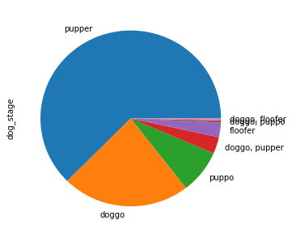

```python
# visualize dog_types
plot = dog_stage.plot.pie(figsize=(5,5))
```

### insights

1- There is a strong postive correlation between Retweet count & Favorite count

2- Pupper is the most common dog_stage

3- doggo, puppo & doggo, floofer are the lowest common type